# UTS SOAL 1

## Pertanyaan

#### 1a. Lakukan analisis dengan teknik yang sudah dipelajari

Analisis data dilakukan dengan menerapkan binary classification untuk memprediksi Employee Attrition menggunakan model logistic regression

#### 1b. Jelaskan mengapa teknik tersebut yang anda pakai

Model logistic regression digunakan karena model ini adalah salah satu model yang secara alami ditujukan untuk penyelesaian kasus binary classification, dimana prediksi hanya berisikan dua class.

- Model ini mudah untuk diimplementasikan, diinterpretasi, serta sangat efisien untuk melatih model.
- Model ini tidak memiliki asumsi terkait distribusi class di feature space.
- Model ini memberikan arah asosiasi dengan variabel respon (positif atau negatif).
- Model ini cepat untuk mengklasifikasikan record baru.
- Model ini baik untuk memprediksi ketika data dapat dipisahkan secara linier.
- Koefisien model dapat digunakan sebagai indikator feature importance.
- Model ini cenderung kecil kemungkinan untuk overfitting, namun pada dimensi data yang tinggi, mungkin perlu digunakan regularisasi untuk menghindari overfitting.

Sumber: https://www.geeksforgeeks.org/advantages-and-disadvantages-of-logistic-regression/

#### 1c. Apakah Anda perlu menggunakan Pre Processing? Jika YA jelaskan PreProcessing apa yang Anda perlukan

Preprocessing yang digunakan dalam membuat model adalah

1. Cek null values
2. Drop kolom data yang kategorikal (nominal dan ordinal)
3. Feature scaling dengan min-max scalling skala 0-1
4. Menyeleksi feature dengan melihat korelasi antara variabel prediktor
5. Membagi data ke train dan test dataset
6. Membuat train dataset memiliki kelas yang seimbang dengan up sample

#### 1d. Hasil apa yang bisa Anda dapatkan dari data yang sudah diolah dan berikan penjelasan apa manfaatnya terkait pengambilan keputusan

Dengan hanya mengandalkan metric accuracy, saya mendapat nilai accuracy final sebesar 0.6218487 dengan menggunakan persentase training dataset 90% dan test dataset 10%, melakukan up sample pada imbalance class di train dataset, serta melakukan feature selection berdasarkan korelasi variabel prediktor dan p-value hasil model iterasi pertama. Hasil accuracy yang diperoleh belum memuaskan, maka langkah selanjutnya yang bisa dilakukan:

- Eliminasi outlier dengan capping dan flooring
- Menggunakan cross validation
- Menggunakan teknik regularisasi (L1 dan L2)
- Menggunakan model binary classification lainnya

Hasil model yang diperoleh diperuntuhkan untuk memprediksi karyawan yang hendak resign (Employee Attrition). Hal ini dapat bermanfaat bagi HRD untuk melakukan tindakan pencegahan terhadap karyawan yang berpotensi besar akan resign berdasarkan ketentuan perusahaan.

## Read Dataset

```r
library(readxl)
df_raw = read_excel("D:/Kuliah/Semester 1/Data Mining dan Business Intelligence/UTS/DataKepuasanPekerja.xlsx", sheet="INX_Future_Inc_Employee_Perform")
head(df_raw)
```

```
## # A tibble: 6 × 28
##   EmpNumber   Age Gender Educa…¹ Marit…² EmpDe…³ EmpJo…⁴ Busin…⁵ Dista…⁶ EmpEd…⁷
##   <chr>     <dbl> <chr>  <chr>   <chr>   <chr>   <chr>   <chr>     <dbl>   <dbl>
## 1 E1001000     32 Male   Market… Single  Sales   Sales … Travel…      10       3
## 2 E1001006     47 Male   Market… Single  Sales   Sales … Travel…      14       4
## 3 E1001007     40 Male   Life S… Married Sales   Sales … Travel…       5       4
## 4 E1001009     41 Male   Human … Divorc… Human … Manager Travel…      10       4
## 5 E1001010     60 Male   Market… Single  Sales   Sales … Travel…      16       4
## 6 E1001011     27 Male   Life S… Divorc… Develo… Develo… Travel…      10       2
## # … with 18 more variables: EmpEnvironmentSatisfaction <dbl>,
## #   EmpHourlyRate <dbl>, EmpJobInvolvement <dbl>, EmpJobLevel <dbl>,
## #   EmpJobSatisfaction <dbl>, NumCompaniesWorked <dbl>, OverTime <chr>,
## #   EmpLastSalaryHikePercent <dbl>, EmpRelationshipSatisfaction <dbl>,
## #   TotalWorkExperienceInYears <dbl>, TrainingTimesLastYear <dbl>,
## #   EmpWorkLifeBalance <dbl>, ExperienceYearsAtThisCompany <dbl>,
## #   ExperienceYearsInCurrentRole <dbl>, YearsSinceLastPromotion <dbl>, …
```

```r
str(df_raw)
```

```
## tibble [1,200 × 28] (S3: tbl_df/tbl/data.frame)
##  $ EmpNumber                   : chr [1:1200] "E1001000" "E1001006" "E1001007" "E1001009" ...
##  $ Age                         : num [1:1200] 32 47 40 41 60 27 50 28 36 38 ...
##  $ Gender                      : chr [1:1200] "Male" "Male" "Male" "Male" ...
##  $ EducationBackground         : chr [1:1200] "Marketing" "Marketing" "Life Sciences" "Human Resources" ...
##  $ MaritalStatus               : chr [1:1200] "Single" "Single" "Married" "Divorced" ...
##  $ EmpDepartment               : chr [1:1200] "Sales" "Sales" "Sales" "Human Resources" ...
##  $ EmpJobRole                  : chr [1:1200] "Sales Executive" "Sales Executive" "Sales Executive" "Manager" ...
##  $ BusinessTravelFrequency     : chr [1:1200] "Travel_Rarely" "Travel_Rarely" "Travel_Frequently" "Travel_Rarely" ...
##  $ DistanceFromHome            : num [1:1200] 10 14 5 10 16 10 8 1 8 1 ...
##  $ EmpEducationLevel           : num [1:1200] 3 4 4 4 4 2 4 2 3 3 ...
##  $ EmpEnvironmentSatisfaction  : num [1:1200] 4 4 4 2 1 4 4 1 1 3 ...
##  $ EmpHourlyRate               : num [1:1200] 55 42 48 73 84 32 54 67 63 81 ...
##  $ EmpJobInvolvement           : num [1:1200] 3 3 2 2 3 3 3 1 4 3 ...
##  $ EmpJobLevel                 : num [1:1200] 2 2 3 5 2 3 1 1 3 3 ...
##  $ EmpJobSatisfaction          : num [1:1200] 4 1 1 4 1 1 2 2 1 3 ...
##  $ NumCompaniesWorked          : num [1:1200] 1 2 5 3 8 1 7 7 9 4 ...
##  $ OverTime                    : chr [1:1200] "No" "No" "Yes" "No" ...
##  $ EmpLastSalaryHikePercent    : num [1:1200] 12 12 21 15 14 21 15 13 14 14 ...
##  $ EmpRelationshipSatisfaction : num [1:1200] 4 4 3 2 4 3 4 4 1 4 ...
##  $ TotalWorkExperienceInYears  : num [1:1200] 10 20 20 23 10 9 4 10 10 10 ...
##  $ TrainingTimesLastYear       : num [1:1200] 2 2 2 2 1 4 2 4 2 4 ...
##  $ EmpWorkLifeBalance          : num [1:1200] 2 3 3 2 3 2 3 3 3 4 ...
##  $ ExperienceYearsAtThisCompany: num [1:1200] 10 7 18 21 2 9 2 7 8 1 ...
##  $ ExperienceYearsInCurrentRole: num [1:1200] 7 7 13 6 2 7 2 7 7 0 ...
##  $ YearsSinceLastPromotion     : num [1:1200] 0 1 1 12 2 1 2 3 0 0 ...
##  $ YearsWithCurrManager        : num [1:1200] 8 7 12 6 2 7 2 7 5 0 ...
##  $ Attrition                   : chr [1:1200] "No" "No" "No" "No" ...
##  $ PerformanceRating           : num [1:1200] 3 3 4 3 3 4 3 3 3 3 ...
```

## Descriptive Statistics

```r
summary(df_raw)
```

```
##   EmpNumber              Age           Gender          EducationBackground
##  Length:1200        Min.   :18.00   Length:1200        Length:1200
##  Class :character   1st Qu.:30.00   Class :character   Class :character
##  Mode  :character   Median :36.00   Mode  :character   Mode  :character
##                     Mean   :36.92
##                     3rd Qu.:43.00
##                     Max.   :60.00
##  MaritalStatus      EmpDepartment       EmpJobRole
##  Length:1200        Length:1200        Length:1200
##  Class :character   Class :character   Class :character
##  Mode  :character   Mode  :character   Mode  :character
##
##
##
##  BusinessTravelFrequency DistanceFromHome EmpEducationLevel
##  Length:1200             Min.   : 1.000   Min.   :1.000
##  Class :character        1st Qu.: 2.000   1st Qu.:2.000
##  Mode  :character        Median : 7.000   Median :3.000
##                          Mean   : 9.166   Mean   :2.893
##                          3rd Qu.:14.000   3rd Qu.:4.000
##                          Max.   :29.000   Max.   :5.000
##  EmpEnvironmentSatisfaction EmpHourlyRate    EmpJobInvolvement  EmpJobLevel
##  Min.   :1.000              Min.   : 30.00   Min.   :1.000     Min.   :1.000
##  1st Qu.:2.000              1st Qu.: 48.00   1st Qu.:2.000     1st Qu.:1.000
##  Median :3.000              Median : 66.00   Median :3.000     Median :2.000
##  Mean   :2.716              Mean   : 65.98   Mean   :2.732     Mean   :2.067
##  3rd Qu.:4.000              3rd Qu.: 83.00   3rd Qu.:3.000     3rd Qu.:3.000
##  Max.   :4.000              Max.   :100.00   Max.   :4.000     Max.   :5.000
##  EmpJobSatisfaction NumCompaniesWorked   OverTime
##  Min.   :1.000      Min.   :0.000      Length:1200
##  1st Qu.:2.000      1st Qu.:1.000      Class :character
##  Median :3.000      Median :2.000      Mode  :character
##  Mean   :2.732      Mean   :2.665
##  3rd Qu.:4.000      3rd Qu.:4.000
##  Max.   :4.000      Max.   :9.000
##  EmpLastSalaryHikePercent EmpRelationshipSatisfaction
##  Min.   :11.00            Min.   :1.000
##  1st Qu.:12.00            1st Qu.:2.000
##  Median :14.00            Median :3.000
##  Mean   :15.22            Mean   :2.725
```

[output cut: 15 more lines]

```
##  Max.   :40.000               Max.   :18.000
##  YearsSinceLastPromotion YearsWithCurrManager  Attrition
##  Min.   : 0.000          Min.   : 0.000       Length:1200
##  1st Qu.: 0.000          1st Qu.: 2.000       Class :character
##  Median : 1.000          Median : 3.000       Mode  :character
##  Mean   : 2.194          Mean   : 4.105
##  3rd Qu.: 3.000          3rd Qu.: 7.000
##  Max.   :15.000          Max.   :17.000
##  PerformanceRating
##  Min.   :2.000
##  1st Qu.:3.000
##  Median :3.000
##  Mean   :2.948
##  3rd Qu.:3.000
##  Max.   :4.000
```

### Check for Null Value

```r
lapply(df_raw,function(x) { length(which(is.na(x)))})
```

```
## $EmpNumber
## [1] 0
##
## $Age
## [1] 0
##
## $Gender
## [1] 0
##
## $EducationBackground
## [1] 0
##
## $MaritalStatus
## [1] 0
##
## $EmpDepartment
## [1] 0
##
## $EmpJobRole
## [1] 0
##
## $BusinessTravelFrequency
## [1] 0
##
## $DistanceFromHome
## [1] 0
##
## $EmpEducationLevel
## [1] 0
##
## $EmpEnvironmentSatisfaction
## [1] 0
##
## $EmpHourlyRate
## [1] 0
##
## $EmpJobInvolvement
## [1] 0
##
## $EmpJobLevel
```

[output cut: 28 more lines]

```
##
## $ExperienceYearsInCurrentRole
## [1] 0
##
## $YearsSinceLastPromotion
## [1] 0
##
## $YearsWithCurrManager
## [1] 0
##
## $Attrition
## [1] 0
##
## $PerformanceRating
## [1] 0
```

```r
df_clean = df_raw
```

### Drop categorical (nominal and ordinal) columns

```r
#library(psych)

#ints<-sapply(df_clean, is.integer)

#df_clean_int = as.data.frame(apply(df_clean[,ints],2,as.numeric))
df_clean_num = df_clean[, sapply(df_clean, is.numeric)]
#str(df_clean_num)
df_clean_num = df_clean_num[c(-3, -4, -7, -8, -11, -14, -19)]
#str(df_clean_num)
```

### Feature Scalling

```r
#install.packages("conflicted")
library(conflicted)
conflict_prefer("apply", "base")
```

```
## [conflicted] Will prefer base::apply over any other package
```

```r
# Create Response Variable as DataFrame
df_target=as.data.frame(df_clean[c(27)])

# Norm Z function declaration
normalisasi=function(x){
  xm=colMeans(x)
  jb=dim(x)[1]
  xc=x-rep(xm,each=jb)
  sdx=apply(x,2,sd)
  xstd=xc/rep(sdx,each=jb)
  output=data.frame(xstd)
  #output=data.frame(xstd,x)
  return(output)
}


# Min-Max Norm function declaration
min_max_norm <- function(x) {
    (x - min(x)) / (max(x) - min(x))
  }

# Normalization
#df_norm = normalisasi(df_clean_num)
df_norm = as.data.frame(lapply(df_clean_num, min_max_norm))

# Outer Join Dataset
df_norm = data.frame(df_target,df_norm)

# Label encoding for response variable
df_norm$Attrition = ifelse(df_norm$Attrition=="Yes",1,0)
df_norm$Attrition = factor(df_norm$Attrition, levels = c(0,1))

#head(df_norm)
#str(df_norm)
#unique(df_norm$Attrition)
```

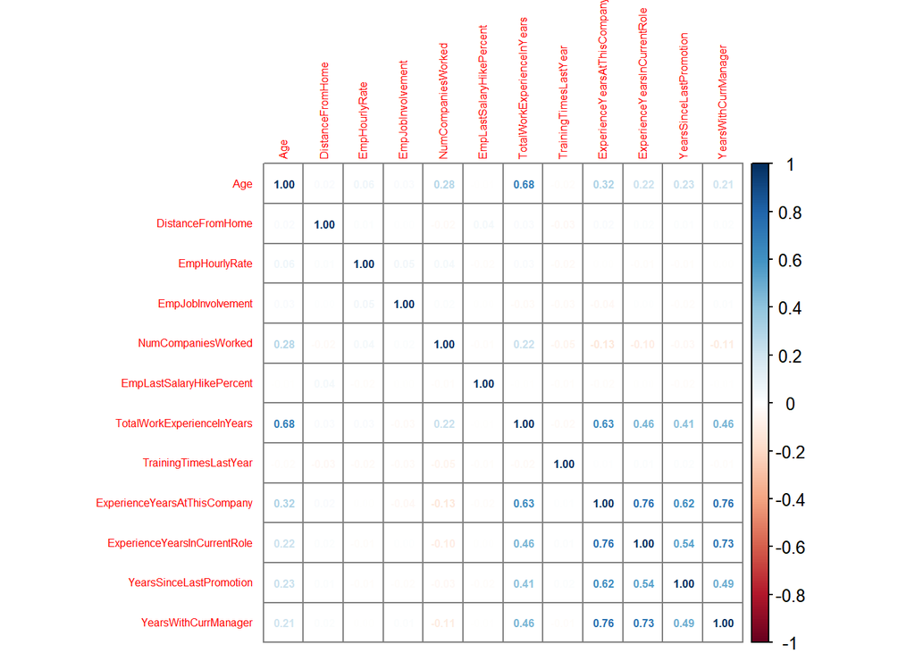

```r
#install.packages("corrplot")
library(psych)
library(corrplot)
#corPlot(cor(df_norm[(-1)]), cex=0.3, tl.cex=1, xlas=3)
corrplot(cor(df_norm[(-1)], df_norm[(-1)]),
         method = c("number"),
         #bg = "grey10",
         addgrid.col = "gray50",
         tl.cex=0.5,
         number.cex=0.5)
```

from this correlation graph, we knew that there are stong correlation (>0.5) between

- Age~TotalWorkExperienceInYears
- TotalWorkExperience~ExperienceYearsAtThisCompany
- ExperienceYearsAtThisCompany~ExperienceYearsInCurrentRole
- ExperienceYearsAtThisCompany~YearsSiceLastPromotion
- ExperienceYearsAtThisCompany~YearsWithCurrentManager
- ExperienceYearsInCurrentRole~YearsSinceLastPromotion
- ExperienceYearsInCurrentRole~YearsWithCurrentManager

So we ned to drop this columns = Age, TotalWorkExperienceInYears, ExperienceYearsAtThisCompany, ExperienceYearsInCurrentRole, YearsSiceLastPromotion, YearsWithCurrentManager,

### Create Class Balanced Train and test Dataset

```r
#install.packages("caret")
library(caret)
'%ni%' = Negate('%in%')
options(scipen=999)

set.seed(100)
str(df_norm)
```

```
## 'data.frame':    1200 obs. of  13 variables:
##  $ Attrition                   : Factor w/ 2 levels "0","1": 1 1 1 1 1 1 1 2 1 1 ...
##  $ Age                         : num  0.333 0.69 0.524 0.548 1 ...
##  $ DistanceFromHome            : num  0.321 0.464 0.143 0.321 0.536 ...
##  $ EmpHourlyRate               : num  0.357 0.171 0.257 0.614 0.771 ...
##  $ EmpJobInvolvement           : num  0.667 0.667 0.333 0.333 0.667 ...
##  $ NumCompaniesWorked          : num  0.111 0.222 0.556 0.333 0.889 ...
##  $ EmpLastSalaryHikePercent    : num  0.0714 0.0714 0.7143 0.2857 0.2143 ...
##  $ TotalWorkExperienceInYears  : num  0.25 0.5 0.5 0.575 0.25 0.225 0.1 0.25 0.25 0.25 ...
##  $ TrainingTimesLastYear       : num  0.333 0.333 0.333 0.333 0.167 ...
##  $ ExperienceYearsAtThisCompany: num  0.25 0.175 0.45 0.525 0.05 0.225 0.05 0.175 0.2 0.025 ...
##  $ ExperienceYearsInCurrentRole: num  0.389 0.389 0.722 0.333 0.111 ...
##  $ YearsSinceLastPromotion     : num  0 0.0667 0.0667 0.8 0.1333 ...
##  $ YearsWithCurrManager        : num  0.471 0.412 0.706 0.353 0.118 ...
```

```r
df_train_test= df_norm[c(-2, -8, -10, -11, -12, -13)]
#df_train_test = df_norm[c(-4, -7)] # Up sample feature selection with 80% training dataset
#df_train_test = df_norm[c(-2, -4, -7)] # Up sample feature selection
#df_train_test = df_norm[c(-2, -3, -4, -7, -12,-13)] #Down sample feature selection
#head(df_train_test)
```

```r
trainDataIndex= createDataPartition(df_train_test$Attrition, p=0.9, list = F)

trainData = df_train_test[trainDataIndex,]
testData = df_train_test[-trainDataIndex,]

# Down sample
set.seed(100)
down_train=downSample(x=trainData[, colnames(trainData)%ni%"Attrition"], y=trainData$Attrition)
#table(down_train$Class)

# Up Sample
set.seed(100)
up_train = upSample(x = trainData[, colnames(trainData)%ni%"Attrition"], y = trainData$Attrition)
table(up_train$Class)
```

```
##
##   0   1
## 920 920
```

### Create Logistic Regression Model

```r
logitmod = glm(Class~., family = "binomial", data=up_train)
summary(logitmod)
```

```
##
## Call:
## glm(formula = Class ~ ., family = "binomial", data = up_train)
##
## Deviance Residuals:
##      Min        1Q    Median        3Q       Max
## -1.86954  -1.10298  -0.00243   1.15110   1.66672
##
## Coefficients:
##                          Estimate Std. Error z value             Pr(>|z|)
## (Intercept)                1.1069     0.2014   5.495         0.0000000391 ***
## DistanceFromHome           0.6156     0.1619   3.802             0.000143 ***
## EmpHourlyRate             -0.2656     0.1661  -1.599             0.109839
## EmpJobInvolvement         -1.8265     0.2030  -8.999 < 0.0000000000000002 ***
## NumCompaniesWorked         0.3591     0.1690   2.126             0.033531 *
## EmpLastSalaryHikePercent  -0.2517     0.1843  -1.366             0.172077
## TrainingTimesLastYear     -0.4710     0.2275  -2.070             0.038468 *
## ---
## Signif. codes:  0 '***' 0.001 '**' 0.01 '*' 0.05 '.' 0.1 ' ' 1
##
## (Dispersion parameter for binomial family taken to be 1)
##
##     Null deviance: 2550.8  on 1839  degrees of freedom
## Residual deviance: 2435.0  on 1833  degrees of freedom
## AIC: 2449
##
## Number of Fisher Scoring iterations: 4
```

### Model Validation using Accuracy Metrics

```r
pred <- predict(logitmod, testData, type = "response")

y_pred_num = ifelse(pred>0.5,1,0)
y_pred = factor(y_pred_num, levels=c(0,1))
y_act = testData$Attrition

mean(y_pred==y_act)
```

```
## [1] 0.6386555
```

## Feature Selection Based On P-Value

### Create Class Balanced Train and test Dataset

```r
#install.packages("caret")
library(caret)
'%ni%' = Negate('%in%')
options(scipen=999)

set.seed(100)
str(df_norm)
```

```
## 'data.frame':    1200 obs. of  13 variables:
##  $ Attrition                   : Factor w/ 2 levels "0","1": 1 1 1 1 1 1 1 2 1 1 ...
##  $ Age                         : num  0.333 0.69 0.524 0.548 1 ...
##  $ DistanceFromHome            : num  0.321 0.464 0.143 0.321 0.536 ...
##  $ EmpHourlyRate               : num  0.357 0.171 0.257 0.614 0.771 ...
##  $ EmpJobInvolvement           : num  0.667 0.667 0.333 0.333 0.667 ...
##  $ NumCompaniesWorked          : num  0.111 0.222 0.556 0.333 0.889 ...
##  $ EmpLastSalaryHikePercent    : num  0.0714 0.0714 0.7143 0.2857 0.2143 ...
##  $ TotalWorkExperienceInYears  : num  0.25 0.5 0.5 0.575 0.25 0.225 0.1 0.25 0.25 0.25 ...
##  $ TrainingTimesLastYear       : num  0.333 0.333 0.333 0.333 0.167 ...
##  $ ExperienceYearsAtThisCompany: num  0.25 0.175 0.45 0.525 0.05 0.225 0.05 0.175 0.2 0.025 ...
##  $ ExperienceYearsInCurrentRole: num  0.389 0.389 0.722 0.333 0.111 ...
##  $ YearsSinceLastPromotion     : num  0 0.0667 0.0667 0.8 0.1333 ...
##  $ YearsWithCurrManager        : num  0.471 0.412 0.706 0.353 0.118 ...
```

```r
df_train_test= df_norm[c(-2, -8, -10, -11, -12, -13, -4, -7)]
#df_train_test = df_norm[c(-4, -7)] # Up sample feature selection with 80% training dataset
#df_train_test = df_norm[c(-2, -4, -7)] # Up sample feature selection
#df_train_test = df_norm[c(-2, -3, -4, -7, -12,-13)] #Down sample feature selection
head(df_train_test)
```

```
##   Attrition DistanceFromHome EmpJobInvolvement NumCompaniesWorked
## 1         0        0.3214286         0.6666667          0.1111111
## 2         0        0.4642857         0.6666667          0.2222222
## 3         0        0.1428571         0.3333333          0.5555556
## 4         0        0.3214286         0.3333333          0.3333333
## 5         0        0.5357143         0.6666667          0.8888889
## 6         0        0.3214286         0.6666667          0.1111111
##   TrainingTimesLastYear
## 1             0.3333333
## 2             0.3333333
## 3             0.3333333
## 4             0.3333333
## 5             0.1666667
## 6             0.6666667
```

```r
trainDataIndex= createDataPartition(df_train_test$Attrition, p=0.9, list = F)

trainData = df_train_test[trainDataIndex,]
testData = df_train_test[-trainDataIndex,]

# Down sample
set.seed(100)
down_train=downSample(x=trainData[, colnames(trainData)%ni%"Attrition"], y=trainData$Attrition)
#table(down_train$Class)

# Up Sample
set.seed(100)
up_train = upSample(x = trainData[, colnames(trainData)%ni%"Attrition"], y = trainData$Attrition)
table(up_train$Class)
```

```
##
##   0   1
## 920 920
```

### Create Logistic Regression Model

```r
logitmod = glm(Class~., family = "binomial", data=up_train)
summary(logitmod)
```

```
##
## Call:
## glm(formula = Class ~ ., family = "binomial", data = up_train)
##
## Deviance Residuals:
##      Min        1Q    Median        3Q       Max
## -1.84767  -1.09418  -0.00416   1.16553   1.64410
##
## Coefficients:
##                       Estimate Std. Error z value             Pr(>|z|)
## (Intercept)             0.9168     0.1775   5.163          0.000000243 ***
## DistanceFromHome        0.5987     0.1610   3.718             0.000201 ***
## EmpJobInvolvement      -1.8533     0.2023  -9.163 < 0.0000000000000002 ***
## NumCompaniesWorked      0.3602     0.1687   2.135             0.032744 *
## TrainingTimesLastYear  -0.4665     0.2272  -2.054             0.040021 *
## ---
## Signif. codes:  0 '***' 0.001 '**' 0.01 '*' 0.05 '.' 0.1 ' ' 1
##
## (Dispersion parameter for binomial family taken to be 1)
##
##     Null deviance: 2550.8  on 1839  degrees of freedom
## Residual deviance: 2439.1  on 1835  degrees of freedom
## AIC: 2449.1
##
## Number of Fisher Scoring iterations: 4
```

### Model Validation using Accuracy Metrics

```r
pred <- predict(logitmod, testData, type = "response")

y_pred_num = ifelse(pred>0.5,1,0)
y_pred = factor(y_pred_num, levels=c(0,1))
y_act = testData$Attrition

mean(y_pred==y_act)
```

```
## [1] 0.6218487
```